# MTH6139 Time Series

Coursework 1

Lovelace Fabrica

Spring term 2026

# Introduction

Natural gas prices are an important factor for households. They rely on natural gas for certain things such as heating, hot water and cooking. The price of gas is influenced by certain factors such as the weather, storage levels and geopolitical events.

In this project, I will be analysing Henry Hub natural gas prices and I will also be using Meta’s prophet forecasting model to predict the future natural gas prices.

# Data

The Henry Hub natural gas prices was taken from the U.S. Energy Information Administration. The data is recorded monthly and it spans from Jan 1997 to Feb 2026. It shows how the natural gas prices changes as the months and years go by.

```
## # A tibble: 6 × 2
##   Date     `Henry Hub Natural Gas Spot Price (Dollars per Million Btu)`
##   <chr>                                                           <dbl>
## 1 Jan-1997                                                         3.45
## 2 Feb-1997                                                         2.15
## 3 Mar-1997                                                         1.89
## 4 Apr-1997                                                         2.03
## 5 May-1997                                                         2.25
## 6 Jun-1997                                                         2.2
```

# Data Preparations

The dataset has been changed into the format in which is needed by the prophet model. ds is the date and y is the natural gas price (Dollars per Millions Btu)

```
## # A tibble: 6 × 2
##   ds             y
##   <date>     <dbl>
## 1 1997-01-01  3.45
## 2 1997-02-01  2.15
## 3 1997-03-01  1.89
## 4 1997-04-01  2.03
## 5 1997-05-01  2.25
## 6 1997-06-01  2.2
```

# Analytical Explanation

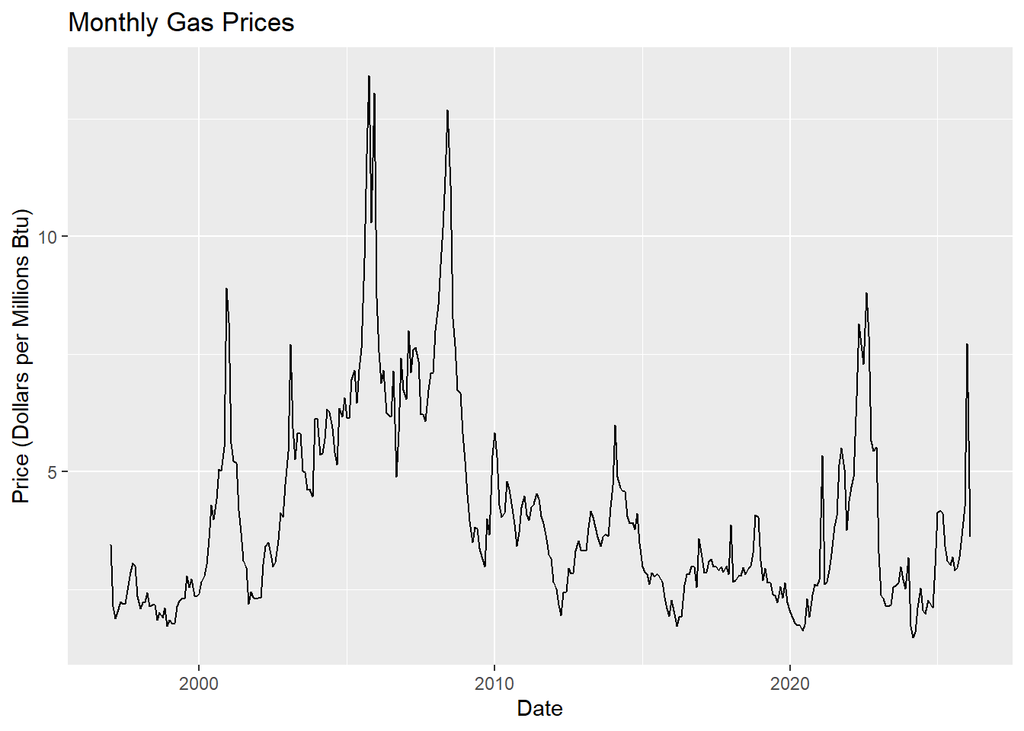

Looking at this graph, gas prices fluctuate significantly over the years. There is a lot of sharp increases and decreases shown on the graph. For example between 2005-2008, gas prices were the highest at around 13 dollars per millions Btu. A reason for this could be that there was a huge rise in demand for energy, so gas prices would increase significantly. Another example is in 2020. Gas prices were so low because of COVID-19. The demand for energy was low, so gas prices had to be reduced and also there was low economic activity. With the data shown on the graph, this shows that natural gas prices are really volatile as they are influenced by certain factors.

# Prophet Model

```
## Disabling weekly seasonality. Run prophet with weekly.seasonality=TRUE to override this.
```

```
## Disabling daily seasonality. Run prophet with daily.seasonality=TRUE to override this.
```

# Forecasting future gas prices

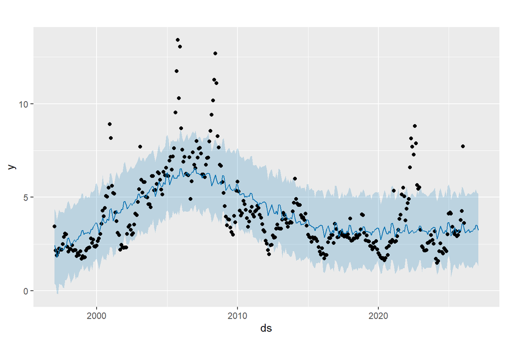

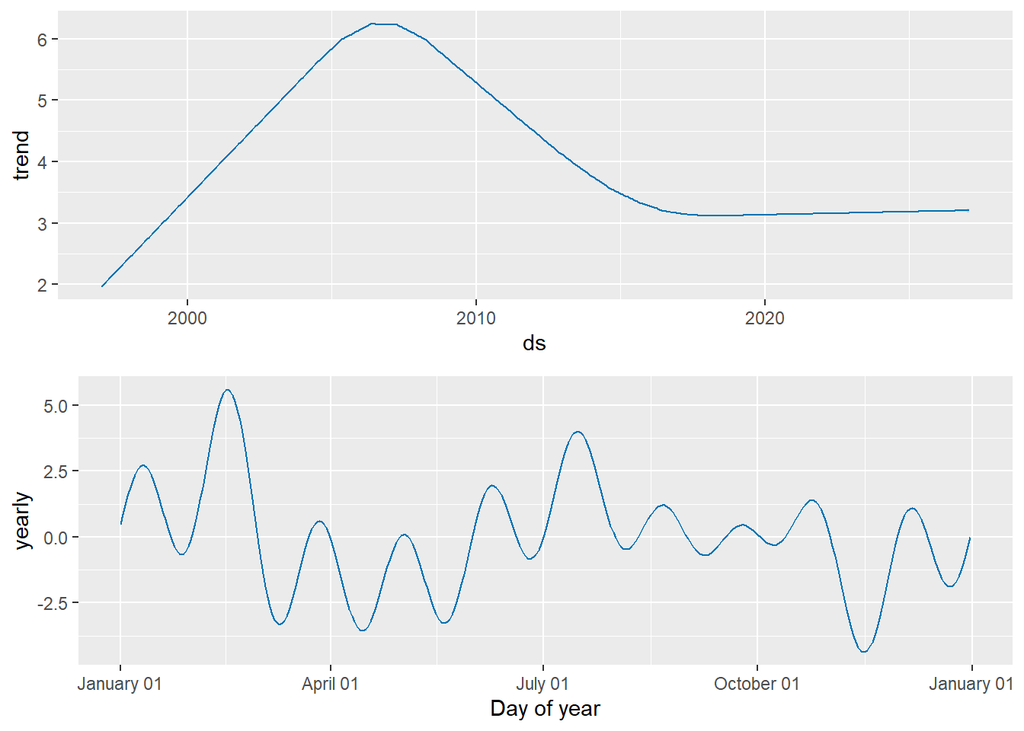

The forecast shows the predicted gas prices for future periods. The forecast uses previous years data to find and make trends and also seasonal patterns.

# Results and Conclusion

The forecast made by the prophet model shows that the natural gas prices are going to remain mostly stable over the next 12 months, with not a lot of fluctuations. The model is able to capture the general trend of the gas prices but it can’t predict the massive spikes or declines as those depend on what is happening around the world and the demand for energy.

In conclusion, the prophet model was used to forecast the price of natural gas monthly based on previous years data. As we look at the graphs, it shows that if there is a high demand for energy, then the natural gas prices increase significantly. If there is no economic activity, then the price of natural gas decreases. The forecast showed us that even if the next 12 months are going to be stable, we can’t predict what’s going to happen in the future e.g. wars, climate change etc.